# Employee Attrition Analaysis

Pearly Merin Paul

8/7/2021

## Introduction

In the below report, we have been provided with the data set `CaseStudy.csv` to analyze the factors that lead to attrition. Our team in DDS Analytics were asked to identify the top three factors that contribute to turnover . Our team had to do an exploratory Data Analysis on the data provided to come up with useful insights. Along with the base data we were provided datasheet `CaseStudy2CompSet No Attrition` to use the models to predict Attrition

And an another datasheet `CaseStudy2CompSet No Salary.csv` to predict the Monthly Income of the Employee.

## Reproducible Research in R

```r
library(magrittr)
library(dplyr)
```

```r
library(ggplot2)
library(Amelia) # Confirm missing value
library(rpart)
library(rattle)
require(caTools)
library(ggcorrplot)
library(randomForest)
library(randomForestSRC)
library(corrplot)
library(cowplot)
library(class)
library(caret)
```

## Loading all the datasheets for analysis

`CaseStudy.csv` : To perform exploratory Data analysis `CaseStudy2CompSetNoSalary.csv` : To predict Salary `CaseStudy2CompSet No Attrition.csv`: To predict Attrition

```r
employee <- read.csv("CaseStudy.csv")

employeeNoAttrition<-read.csv("data/CaseStudy2CompSet No Attrition.csv")
employeeNoSalary<-read.csv("data/CaseStudy2CompSetNoSalary.csv")

employeedata<-employee
 employee <- select(employee,-c(ID, EmployeeCount, EmployeeNumber, Over18,StandardHours))

employeetotal<-employee

glimpse(employeetotal)
```

```
## Rows: 870
## Columns: 31
## $ Age                      <int> 32, 40, 35, 32, 24, 27, 41, 37, 34, 34, 43, 2~
## $ Attrition                <chr> "No", "No", "No", "No", "No", "No", "No", "No~
## $ BusinessTravel           <chr> "Travel_Rarely", "Travel_Rarely", "Travel_Fre~
## $ DailyRate                <int> 117, 1308, 200, 801, 567, 294, 1283, 309, 133~
## $ Department               <chr> "Sales", "Research & Development", "Research ~
## $ DistanceFromHome         <int> 13, 14, 18, 1, 2, 10, 5, 10, 10, 10, 6, 1, 7,~
## $ Education                <int> 4, 3, 2, 4, 1, 2, 5, 4, 4, 4, 3, 2, 3, 1, 2, ~
## $ EducationField           <chr> "Life Sciences", "Medical", "Life Sciences", ~
## $ EnvironmentSatisfaction  <int> 2, 3, 3, 3, 1, 4, 2, 4, 3, 4, 1, 3, 3, 3, 4, ~
## $ Gender                   <chr> "Male", "Male", "Male", "Female", "Female", "~
## $ HourlyRate               <int> 73, 44, 60, 48, 32, 32, 90, 88, 87, 92, 81, 4~
## $ JobInvolvement           <int> 3, 2, 3, 3, 3, 3, 4, 2, 3, 2, 2, 3, 3, 3, 3, ~
## $ JobLevel                 <int> 2, 5, 3, 3, 1, 3, 1, 2, 1, 2, 5, 1, 3, 1, 1, ~
```

[output cut: 18 more lines]

```r
employeetotal1<-filter(employeetotal,Attrition=="Yes")
```

## Overall Attrition Analysis

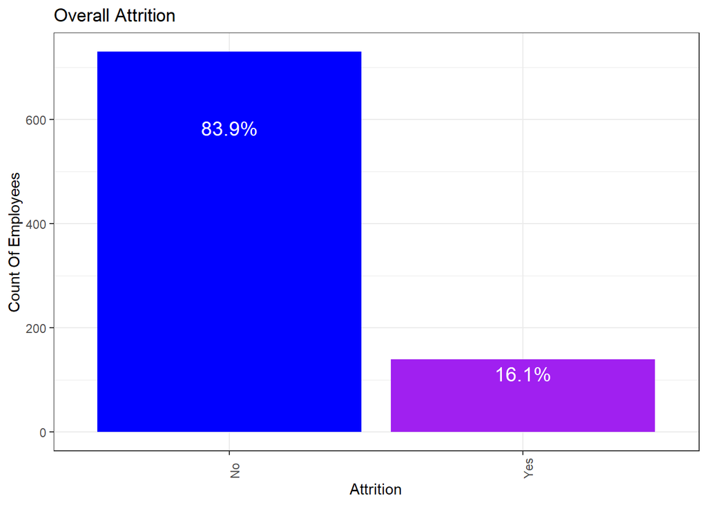

```r
dt <- employeedata%>%
  dplyr::group_by(Attrition)%>%
  dplyr::tally()%>%
  dplyr::mutate(percent=n/sum(n))

theme_set(theme_bw())  # pre-set the bw theme.
 ggplot(data = dt,aes(x= Attrition, y = n))+ geom_bar(stat="identity",fill=c("blue","purple"))+geom_text(aes(label=paste0(sprintf("%1.1f", percent*100),"%")), position=position_stack(vjust=.8), colour="white", size = 5)+theme(axis.text.x = element_text(angle = 90,hjust =0 )) +
   ggtitle("Overall Attrition")+ylab("Count Of Employees")
```

## Cleaning Of the data

In this chunk we have done the data cleaning . HEre were have take the quantitative variables in the data and converted them into categorical variable by this we can get a better model and do exploratory data anlysis on the data.

```r
employeedata<-employee

employeedata$Age <- cut(employeedata$Age,breaks=c(-Inf,20, 30, 40, 50, 60,Inf),labels=c("0-19 years","20-29 years","30-39 years","40-49 years","50-59 years","60 +"),right=FALSE)


employeedata$DailyRate <- cut(employeedata$DailyRate,breaks=c(-Inf,500, 1000,1500, 2000,Inf),labels=c("0-499 Range","500-999 Range","1000-1499 Range","1500 + Range","60 +"),right=FALSE)


employeedata$DistanceFromHome <- cut(employeedata$DistanceFromHome,breaks=c(-Inf,10, 20,30,Inf),labels=c("1-9 miles","20-29 miles","30-40 miles","40+ miles" ),right=FALSE)


employeedata$MonthlyIncome <- cut(employeedata$MonthlyIncome,breaks=c(-Inf,5000, 10000,20000,Inf),labels=c("Low","Medium","Higher","Highest" ),right=FALSE)



employeedata$HourlyRate <- cut(employeedata$HourlyRate,breaks=c(-Inf,50,100, Inf),labels=c("0-150 dollars","50-100 dollars","100+ dollars" ),right=FALSE)




employeedata$MonthlyRate <- cut(employeedata$MonthlyRate,breaks=c(-Inf,5000, 10000,20000,Inf),labels=c("Low","Medium","Higher","Highest" ),right=FALSE)

employeedata$YearsAtCompany <- cut(employeedata$YearsAtCompany,breaks=c(-Inf, 10,15,Inf),labels=c("1-9 years","10 -14 years","15 + years" ),right=FALSE)

employeedata$TotalWorkingYears <- cut(employeedata$TotalWorkingYears,breaks=c(-Inf, 10,15,Inf),labels=c("1-9 years","10 -14 years","15 + years" ),right=FALSE)






employeedata$Education=as.factor(if_else(employeedata$Education == 1,"Below College", if_else(employeedata$Education == 2, "College", if_else(employeedata$Education == 3, "Bachelor", if_else(employeedata$Education == 4, "Master","Doctor")))))

employeedata$EnvironmentSatisfaction = as.factor(if_else(employeedata$EnvironmentSatisfaction == 1,"Low",if_else(employeedata$EnvironmentSatisfaction == 2, "Medium", if_else(employeedata$EnvironmentSatisfaction == 3, "High", "Very High"))))

employeedata$JobInvolvement = as.factor(if_else(employeedata$JobInvolvement == 1,"Low",if_else(employeedata$JobInvolvement == 2, "Medium",if_else(employeedata$JobInvolvement == 3, "High", "Very High"))))


employeedata$JobSatisfaction = as.factor(if_else(employeedata$JobSatisfaction == 1, "Low",if_else(employeedata$JobSatisfaction == 2, "Medium",if_else(employeedata$JobSatisfaction == 3, "High","Very High"))))

employeedata$PerformanceRating = as.factor(if_else(employeedata$PerformanceRating == 1, "Low",if_else(employeedata$PerformanceRating == 2, "Good", if_else(employeedata$PerformanceRating == 3, "Excellent", "Outstanding"))))

employeedata$RelationshipSatisfaction = as.factor(if_else(employeedata$RelationshipSatisfaction == 1, "Low",if_else(employeedata$RelationshipSatisfaction == 2, "Medium", if_else(employeedata$RelationshipSatisfaction == 3, "High", "Very High"))))

 employeedata$WorkLifeBalance = as.factor(if_else(employeedata$WorkLifeBalance == 1, "Bad",if_else(employeedata$WorkLifeBalance == 2, "Good", if_else(employeedata$WorkLifeBalance == 3, "Better", "Best"))))



employeedata$JobLevel = as.factor(if_else(employeedata$JobLevel == 1, "Low",if_else(employeedata$JobLevel == 2, "Medium",if_else(employeedata$JobLevel  == 3, "High","Very High"))))


employeedata$YearsSinceLastPromotion = cut(employeedata$YearsSinceLastPromotion ,breaks=c(-Inf, 10,15,Inf),labels=c("1-9 years","10 -14 years","15 + years" ),right=FALSE)

employeedata$PercentSalaryHike  = cut(employeedata$PercentSalaryHike  ,breaks=c(-Inf, 10,15,20,Inf),labels=c("1-9 percent","10 -14 percent","15 + percent","20+ percent" ),right=FALSE)

employeedata$YearsInCurrentRole= cut(employeedata$YearsInCurrentRole ,breaks=c(-Inf, 10,15,20,Inf),labels=c("1-9 years","10 -14 years","15 + years","20+ years" ),right=FALSE)


employeedata$YearsWithCurrManager= cut(employeedata$YearsWithCurrManager ,breaks=c(-Inf, 10,15,20,Inf),labels=c("1-9 years","10 -14 years","15 + years","20+ years" ),right=FALSE)



employeedata$NumCompaniesWorked= cut(employeedata$NumCompaniesWorked ,breaks=c(-Inf, 3,6,9,Inf),labels=c("0-2 years","3-5 years","7-8 years","9+ years" ),right=FALSE)
```

## Correlation Plot

[output not shown]

[figure not shown]

## 1. What are the major factors that impact employee Attrition and income benefits of an employee

Benefits of an employee play a major role in the employees attrition rate. An employee who is payed well tend to be more happy and stick with the company .